# Mini Project 2

Anurag Nepal

2026-03-10

## Part 1 - Exploratory Data Analysis (EDA)

```r
raw_housing_df <- read.csv("housing_data.csv")

raw_housing_df$renovated <- as.factor(raw_housing_df$renovated)

split_indices <- createDataPartition(raw_housing_df$price, p = 0.8, list = FALSE)
housing_train <- raw_housing_df[split_indices, ]
housing_test <- raw_housing_df[-split_indices, ]
```

The dataset is being split into training and testing sets. This is done early so information from the test set does not accidentally leak into the exploratory analysis or the pre-processing steps.

### 1.1 Dataset Structure & Missing Values

```r
summary(housing_train)
```

```
##    size_sqft       bedrooms          age           distance_city
##  Min.   : 318   Min.   :0.000   Min.   :  0.0982   Min.   : 1.100
##  1st Qu.:1488   1st Qu.:3.000   1st Qu.:  6.4252   1st Qu.: 8.409
##  Median :1812   Median :4.000   Median : 15.0245   Median :15.182
##  Mean   :1811   Mean   :3.595   Mean   : 20.9158   Mean   :15.164
##  3rd Qu.:2121   3rd Qu.:4.000   3rd Qu.: 29.5264   3rd Qu.:21.501
##  Max.   :3783   Max.   :8.000   Max.   :153.2968   Max.   :29.930
##  NA's   :15                     NA's   :15
##    crime_rate        renovated     price        price_per_sqft
##  Min.   : 0.003682   0:279     Min.   : 12023   Min.   : 23.1
##  1st Qu.: 1.334231   1:121     1st Qu.:227639   1st Qu.:144.6
##  Median : 3.276604             Median :292352   Median :162.1
##  Mean   : 4.983183             Mean   :295020   Mean   :164.4
##  3rd Qu.: 6.992979             3rd Qu.:347484   3rd Qu.:183.4
##  Max.   :27.816081             Max.   :961212   Max.   :455.7
##                                                 NA's   :15
```

```r
na_summary <- data.frame(Missing_Count = colSums(is.na(housing_train)))
knitr::kable(na_summary, caption = "Missing Values by Feature")
```

Missing Values by Feature

|  | Missing_Count |
| --- | --- |
| size_sqft | 15 |
| bedrooms | 0 |
| age | 15 |
| distance_city | 0 |
| crime_rate | 0 |
| renovated | 0 |
| price | 0 |
| price_per_sqft | 15 |

```r
mcar_result <- mcar_test(raw_housing_df)
print(mcar_result)
```

```
## # A tibble: 1 × 4
##   statistic    df p.value missing.patterns
##       <dbl> <dbl>   <dbl>            <int>
## 1      16.5    13   0.223                3
```

Missing values are present in a few of the predictors (`size_sqft`,`age` and `prize_per_sqft`). If every row with a missing value is dropped, a massive chunk of the training data will be lost. So, these missing values are going to be imputed later.

### 1.2 Distributions, Skewness, and Outliers

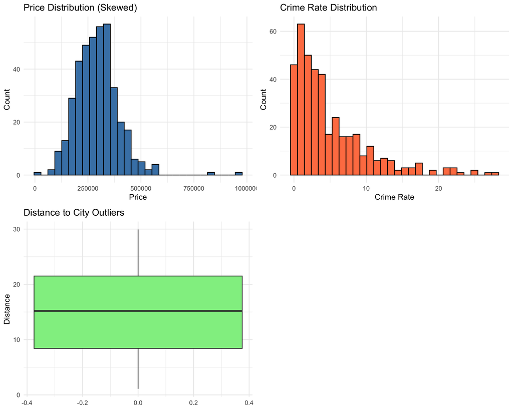

```r
plot_price_dist <- ggplot(housing_train, aes(x = price)) +
  geom_histogram(bins = 30, fill = "steelblue", color = "black") +
  theme_minimal() +
  labs(title = "Price Distribution (Skewed)", x = "Price", y = "Count")

plot_crime_dist <- ggplot(housing_train, aes(x = crime_rate)) +
  geom_histogram(bins = 30, fill = "coral", color = "black") +
  theme_minimal() +
  labs(title = "Crime Rate Distribution", x = "Crime Rate", y = "Count")

plot_dist_outliers <- ggplot(housing_train, aes(y = distance_city)) +
  geom_boxplot(fill = "lightgreen") +
  theme_minimal() +
  labs(title = "Distance to City Outliers", y = "Distance")

grid.arrange(plot_price_dist, plot_crime_dist, plot_dist_outliers, ncol=2)
```

### 1.3 Correlation & Leakage Detection

The relationships between the numeric variables are checked.

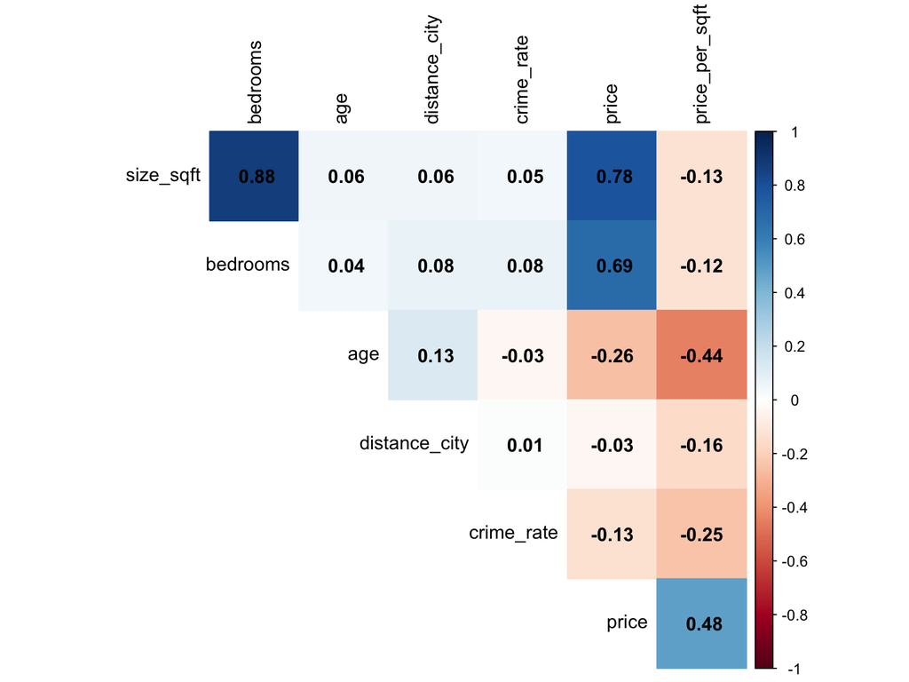

```r
numeric_subset <- housing_train %>% dplyr::select_if(is.numeric)
correlation_matrix <- cor(numeric_subset, use = "complete.obs")

corrplot(correlation_matrix, method = "color", type = "upper",
         addCoef.col = "black", tl.col = "black", diag = FALSE)
```

### Preprocessing Plan

1. **Remove leakage:** The `price_per_sqft` variable will be dropped.
2. **Handle NAs:** Missing numbers will be imputed with the median, and missing categories will be imputed with the mode. Missingness indicators will also be added.
3. **Handle outliers:** Instead of deleting outliers, they will be capped at the 5th and 95th percentiles.
4. **Transform and scale:** The predictors will need to be standardized so Ridge and Lasso work properly, and the skewed variables (`price` and `crime_rate`) will be log-transformed.

## Part 2 - Experimental Pipelines

```r
# Cross-Validation Configuration
cv_control <- trainControl(method = "cv", number = 10)

# Summary function for Log-transformed models (Back-transforms to original scale)
exp_summary <- function(data, lev = NULL, model = NULL) {
  obs <- exp(data$obs)
  pred <- exp(data$pred)
  c(RMSE = RMSE(pred, obs), Rsquared = R2(pred, obs), MAE = MAE(pred, obs))
}

cv_control_log <- trainControl(method = "cv", number = 10, summaryFunction = exp_summary)

# Storage for results
performance_metrics_storage <- list()
test_metrics_storage <- list()
```

```r
# Extract CV performance from caret object
extract_performance <- function(model_obj, pipeline_label, model_type) {
  best_row <- model_obj$results[which.min(model_obj$results$RMSE), ]
  data.frame(
    Pipeline = pipeline_label,
    Model = model_type,
    RMSE = paste0(round(best_row$RMSE, 2), " (± ", round(best_row$RMSESD, 2), ")"),
    MAE = paste0(round(best_row$MAE, 2), " (± ", round(best_row$MAESD, 2), ")"),
    RMSE_Num = best_row$RMSE
  )
}

# Calculate performance on unseen test set
get_test_perf <- function(model_obj, test_data, label, model_type, is_log = FALSE) {
  preds <- predict(model_obj, newdata = test_data)
  obs <- test_data$price
  if(is_log) preds <- exp(preds)

  data.frame(
    Pipeline = label,
    Model = model_type,
    Test_RMSE = round(RMSE(preds, obs), 2),
    Test_MAE = round(MAE(preds, obs), 2)
  )
}

# Unified Imputation Function (Ensures Test uses Training stats)
impute_data <- function(target_df, reference_df) {
  res_df <- target_df
  for(nm in names(res_df)) {
    if(is.numeric(res_df[[nm]])) {
      res_df[[nm]][is.na(res_df[[nm]])] <- median(reference_df[[nm]], na.rm = TRUE)
    } else {
      mode_val <- names(sort(table(reference_df[[nm]]), decreasing = TRUE))[1]
      res_df[[nm]][is.na(res_df[[nm]])] <- mode_val
    }
  }
  return(res_df)
}
```

### Pipeline 0: Baseline

The leakage variable is dropped, and any rows with NA values are removed. No scaling or transformations are applied.

```r
housing_train_clean <- housing_train %>% dplyr::select(-price_per_sqft)
housing_test_clean  <- housing_test %>% dplyr::select(-price_per_sqft)

train_p0 <- na.omit(housing_train_clean)
test_p0  <- na.omit(housing_test_clean)

# Train
fit_p0_ols   <- train(price ~ ., data = train_p0, method = "lm", trControl = cv_control)
fit_p0_ridge <- train(price ~ ., data = train_p0, method = "glmnet",
                      tuneGrid = expand.grid(alpha = 0, lambda = seq(0.1, 10, length=5)),
                      trControl = cv_control)

performance_metrics_storage[[1]] <- extract_performance(fit_p0_ols, "P0_Baseline", "OLS")
performance_metrics_storage[[2]] <- extract_performance(fit_p0_ridge, "P0_Baseline", "Ridge")
test_metrics_storage[[1]] <- get_test_perf(fit_p0_ols, test_p0, "P0_Baseline", "OLS")
test_metrics_storage[[2]] <- get_test_perf(fit_p0_ridge, test_p0, "P0_Baseline", "Ridge")
```

### Pipeline 1: Imputation

All rows are kept by filling in missing values with the median. Scaling is still not applied.

```r
train_p1 <- impute_data(housing_train_clean, housing_train_clean)
test_p1  <- impute_data(housing_test_clean, housing_train_clean)

# Train
fit_p1_ols   <- train(price ~ ., data = train_p1, method = "lm", trControl = cv_control)
fit_p1_ridge <- train(price ~ ., data = train_p1, method = "glmnet",
                      tuneGrid = expand.grid(alpha = 0, lambda = seq(0.1, 10, length=5)),
                      trControl = cv_control)

# Evaluate
performance_metrics_storage[[3]] <- extract_performance(fit_p1_ols, "P1_Imputed", "OLS")
performance_metrics_storage[[4]] <- extract_performance(fit_p1_ridge, "P1_Imputed", "Ridge")
test_metrics_storage[[3]] <- get_test_perf(fit_p1_ols, test_p1, "P1_Imputed", "OLS")
test_metrics_storage[[4]] <- get_test_perf(fit_p1_ridge, test_p1, "P1_Imputed", "Ridge")
```

### Pipeline 2: Imputation + Missing Indicators

This is the same as Pipeline 1, but a binary column is added to flag where the missing values originally were before they were imputed.

```r
# Add Indicators
add_indicators <- function(df) mutate(df, across(everything(), is.na, .names = "na_{.col}"))

train_p2_raw <- add_indicators(housing_train_clean)
test_p2_raw  <- add_indicators(housing_test_clean)

# 2. Impute
train_p2_imputed <- impute_data(train_p2_raw, train_p2_raw)
test_p2_imputed  <- impute_data(test_p2_raw, train_p2_raw)

# This identifies columns where all values are the same (e.g., all FALSE)
nzv_cols <- nearZeroVar(train_p2_imputed)

if(length(nzv_cols) > 0) {
  train_p2 <- train_p2_imputed[, -nzv_cols]
  test_p2  <- test_p2_imputed[, -nzv_cols]
} else {
  train_p2 <- train_p2_imputed
  test_p2  <- test_p2_imputed
}

# Train
fit_p2_ols   <- train(price ~ ., data = train_p2, method = "lm", trControl = cv_control)
fit_p2_ridge <- train(price ~ ., data = train_p2, method = "glmnet",
                      tuneGrid = expand.grid(alpha = 0, lambda = seq(0.1, 10, length=5)),
                      trControl = cv_control)

# Evaluate
performance_metrics_storage[[5]] <- extract_performance(fit_p2_ols, "P2_Indicators", "OLS")
performance_metrics_storage[[6]] <- extract_performance(fit_p2_ridge, "P2_Indicators", "Ridge")
test_metrics_storage[[5]] <- get_test_perf(fit_p2_ols, test_p2, "P2_Indicators", "OLS")
test_metrics_storage[[6]] <- get_test_perf(fit_p2_ridge, test_p2, "P2_Indicators", "Ridge")
```

### Pipeline 3: Normalization

```r
# Identify numeric columns (excluding price)
num_cols <- names(train_p2)[sapply(train_p2, is.numeric) & names(train_p2) != "price"]

# Calculate scaling parameters from train
train_means <- colMeans(train_p2[, num_cols])
train_sds   <- apply(train_p2[, num_cols], 2, sd)

# Scale both
train_p3 <- train_p2
test_p3  <- test_p2
train_p3[num_cols] <- scale(train_p2[num_cols], center = train_means, scale = train_sds)
test_p3[num_cols]  <- scale(test_p2[num_cols], center = train_means, scale = train_sds)

# Train
fit_p3_ridge <- train(price ~ ., data = train_p3, method = "glmnet",
                      tuneGrid = expand.grid(alpha = 0, lambda = seq(0.1, 10, length=5)),
                      trControl = cv_control)
fit_p3_lasso <- train(price ~ ., data = train_p3, method = "glmnet",
                      tuneGrid = expand.grid(alpha = 1, lambda = seq(0.1, 10, length=5)),
                      trControl = cv_control)

# Evaluate
performance_metrics_storage[[7]] <- extract_performance(fit_p3_ridge, "P3_Normalized", "Ridge")
performance_metrics_storage[[8]] <- extract_performance(fit_p3_lasso, "P3_Normalized", "Lasso")
test_metrics_storage[[7]] <- get_test_perf(fit_p3_ridge, test_p3, "P3_Normalized", "Ridge")
test_metrics_storage[[8]] <- get_test_perf(fit_p3_lasso, test_p3, "P3_Normalized", "Lasso")
```

### Pipeline 4: Full Preprocessing

Imputation, indicators, scaling, outlier capping, and log transformations for skewed variables are all included.

```r
# Log Transforms
train_p4 <- train_p2 %>% mutate(price = log(price), crime_rate = log(crime_rate + 1))
test_p4  <- test_p2  %>% mutate(crime_rate = log(crime_rate + 1)) # Price stays original for get_test_perf

# Capping (Winsorization) using Training Quantiles
for(nm in num_cols) {
  qnts <- quantile(train_p4[[nm]], probs = c(.05, .95), na.rm = TRUE)
  train_p4[[nm]] <- pmin(pmax(train_p4[[nm]], qnts[1]), qnts[2])
  test_p4[[nm]]  <- pmin(pmax(test_p4[[nm]], qnts[1]), qnts[2])
}

# Re-scale based on the new P4 training distributions
train_p4_means <- colMeans(train_p4[, num_cols])
train_p4_sds   <- apply(train_p4[, num_cols], 2, sd)

train_p4[num_cols] <- scale(train_p4[num_cols], center = train_p4_means, scale = train_p4_sds)
test_p4[num_cols]  <- scale(test_p4[num_cols], center = train_p4_means, scale = train_p4_sds)

# Train
fit_p4_ridge <- train(price ~ ., data = train_p4, method = "glmnet",
                      tuneGrid = expand.grid(alpha = 0, lambda = seq(0.001, 0.1, length=5)),
                      trControl = cv_control_log)
fit_p4_lasso <- train(price ~ ., data = train_p4, method = "glmnet",
                      tuneGrid = expand.grid(alpha = 1, lambda = seq(0.001, 0.1, length=5)),
                      trControl = cv_control_log)

# Evaluate
performance_metrics_storage[[9]] <- extract_performance(fit_p4_ridge, "P4_Full_Processing", "Ridge")
performance_metrics_storage[[10]] <- extract_performance(fit_p4_lasso, "P4_Full_Processing", "Lasso")

test_metrics_storage[[9]] <- get_test_perf(fit_p4_ridge, test_p4, "P4_Full_Processing", "Ridge", is_log = TRUE)
test_metrics_storage[[10]] <- get_test_perf(fit_p4_lasso, test_p4, "P4_Full_Processing", "Lasso", is_log = TRUE)
```

### 2.1 Summary Comparison Table

```r
final_results <- bind_rows(performance_metrics_storage)
knitr::kable(final_results %>% dplyr::select(-RMSE_Num), caption = "Final Model Comparison")
```

Final Model Comparison

| Pipeline | Model | RMSE | MAE |
| --- | --- | --- | --- |
| P0_Baseline | OLS | 45814.87 (± 18091.58) | 31707.57 (± 6125.63) |
| P0_Baseline | Ridge | 46006.74 (± 20310.99) | 32668.45 (± 6990.74) |
| P1_Imputed | OLS | 50966.55 (± 26322.97) | 33785.18 (± 8091.42) |
| P1_Imputed | Ridge | 52966.87 (± 22409.28) | 34312.07 (± 6827.17) |
| P2_Indicators | OLS | 52885.15 (± 21853.99) | 34117.72 (± 6305.89) |
| P2_Indicators | Ridge | 52898.24 (± 23144.2) | 34616.26 (± 7517.24) |
| P3_Normalized | Ridge | 52897.8 (± 22669.91) | 34422.23 (± 6500.04) |
| P3_Normalized | Lasso | 50165.97 (± 29013.94) | 34042.62 (± 10690.89) |
| P4_Full_Processing | Ridge | 57576.54 (± 22524.34) | 38944.28 (± 8347.26) |
| P4_Full_Processing | Lasso | 57715.22 (± 20603.1) | 38836.25 (± 6111.35) |

```r
test_results_final <- bind_rows(test_metrics_storage)
knitr::kable(test_results_final, caption = "Model Performance on Unseen Test Data")
```

Model Performance on Unseen Test Data

| Pipeline | Model | Test_RMSE | Test_MAE |
| --- | --- | --- | --- |
| P0_Baseline | OLS | 63202.49 | 36907.90 |
| P0_Baseline | Ridge | 65040.12 | 38098.34 |
| P1_Imputed | OLS | 63571.48 | 38038.64 |
| P1_Imputed | Ridge | 65069.86 | 39078.81 |
| P2_Indicators | OLS | 63571.48 | 38038.64 |
| P2_Indicators | Ridge | 65069.86 | 39078.81 |
| P3_Normalized | Ridge | 65069.86 | 39078.81 |
| P3_Normalized | Lasso | 63466.54 | 37947.23 |
| P4_Full_Processing | Ridge | 71259.84 | 43344.54 |
| P4_Full_Processing | Lasso | 70895.78 | 43256.51 |

### 2.2 Performance Plot

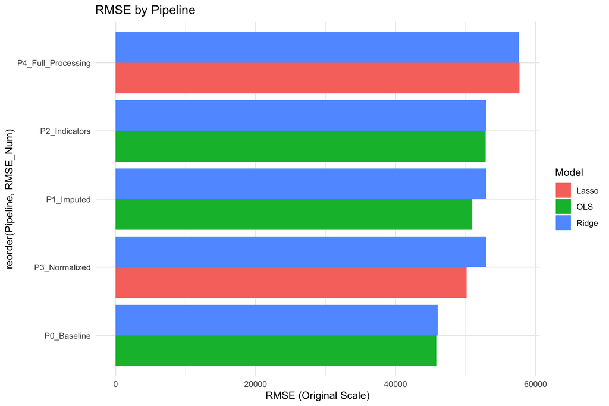

```r
ggplot(final_results, aes(x = reorder(Pipeline, RMSE_Num), y = RMSE_Num, fill = Model)) +
  geom_bar(stat = "identity", position="dodge") +
  coord_flip() + theme_minimal() + labs(title = "RMSE by Pipeline", y = "RMSE (Original Scale)")
```

## Part 3 - Interpretation

- **Which pipeline performed best under RMSE and MAE?**

Pipeline 0 (Baseline - OLS) performed the best, achieving the lowest Mean RMSE of 45814.87 and the lowest mean absolute error of 31707.57 for the training set. It was still the best for the test set as well with lowest Mean RMSE of 63202.49 and the lowest mean absolute error of 36907.90.

- **Did complete-case analysis hurt performance? Why?**

No, complete-case analysis (Pipeline 0, dropping NAs) significantly improved performance compared to all imputation methods. The RMSE jumped from ~46k in Pipeline 0 up to ~52k in Pipeline 1 (Imputation).

This is because the missing data in this dataset is **Missing Completely At Random (MCAR)**.And, we confirmed this statistically during our EDA using Little’s MCAR test, which yielded a statistic of 16.50 and a p-value of 0.223. Since $p > 0.05$, we fail to reject the null hypothesis, formally confirming the MCAR assumption.

When data is perfectly MCAR, dropping rows simply leaves a smaller, but fully representative and unbiased sample. Conversely, Pipeline 1 used median/mode imputation, which artificially compressed the natural variance of the variables, distorted the distribution, and introduced noise that confused the model, which might have resulted in worse predictive performance.

- **Did normalization improve Ridge/Lasso?**

- **Did missingness indicators help?**

## Part 4 - Reflection

**When does preprocessing matter most?**

Preprocessing is necessary when using algorithms that make strict geometric or scale assumptions. It is mandatory for distance-based models (KNN) and regularized models (Ridge/Lasso) where unequal scales would lead to biased penalties. It is also critical if data is Missing Not At Random (MNAR), as preprocessing (indicators) is the only way to capture the hidden signal in the missingness.

**When does it matter less?**

It matters less when the data is already in a meaningful linear scale and you are using OLS, which is scale-invariant as it adjusts coefficients to compensate for scale. It is also less critical for tree-based models (Random Forests/XGBoost), which are robust to outliers and do not require normalization or handle non-linearities intrinsically.

**What mistakes would inflate performance estimates?**

The biggest mistake is Data Leakage, keeping price_per_sqft would allow the model to cheat using the target’s own formula, leading to a perfect but useless RMSE. And, calculating medians or scaling factors using the entire dataset before the split would allow information from the test set to influence the training, creating an over-optimistic but non-generalisable model.